# Introduction to R Workshop

Sharks International 2018

Lindsay Davison, Seb Pardo, Chris Mull, Dovi Kacev

June 3rd, 2018

# Introduction to R programming Workshop June 03 2018

## What we will cover today

This course is intended for people who are interested in learning the basics of programming using the R statistical programming language. No experience in R or programming is necessary! Whether you are an early career scientist or a professional looking to expand your skill set, this course will open the door to a powerful tool that is quickly becoming the gold standard in the biological sciences and essential for analyzing ecological data. This course will cover the basics of programming in R, including writing code, loading data, data manipulation (subset, min, max, summary tables), data visualization, elementary data analysis (e.g. t-test, anovas), and linear modeling. It will also provide a guide to get you acquainted with the (seemingly endless) resources available online, which will help you continue learning about R.

## Who we are

[figure not shown]

**Dr. Dovi Kacev**  
From ugly duckling  
to competent programmR  
Shark scientist too

[figure not shown]

**Lindsay Davidson** Lindsay wants to get your science R-ipped! She has done the heavy-lifting of learning R and has worked tirelessly on her curls and push-ups to get the dplyr pipes that will change the way you do science. Outside of the gym, she works to inform conservation and management priorities for shark and ray species.

[figure not shown]

**Dr. Seb Pardo** As a member of Team Cannonball, Seb will help you program in R efficiently to ensure your code flies! When not going Bayesian, he spends his time working with R code studying a broad range of taxa, from birds, to sharks, rays, and even Atlantic salmon.

[figure not shown]

**Dr. Christopher Mull** Chris (AKA Drsharkbrain) spends his time shreddin’ the gnar and codin’ in R. When he isn’t busy studying shark and ray brains at Simon Fraser University he can be found in the studio, RStudio, laying that sweet RMarkdown. Chris has spent too many years of his life painstakingly crafting the most radical code and exploring the deep mysteries of the shark and ray tree of life. He is sure to help make your functions the object of envy for all in your workspace.

## Other stuff

For today you will need to have access to a computer with the latest version of [R (v3.3 or greater)](https://www.r-project.org/) and the latest version of [RStudio](https://www.rstudio.com/) installed.

# Using R

## R Basics, Objects, Operators

Annote your files by using # before the text. Save you R code with ctrl-s. Note your objects will not be saved, just your R script!

Create an object `a` using the `<-` syntax. Here you are creating an object called `a` that is the sum of 1+1.

```r
a <- 1 + 1
```

What is `a`?

```r
a
```

```
## [1] 2
```

Create a new object called `a` and overwrite the old a - **note**: R will not tell you if you overwrite an object.

```r
a <- 10
```

What is the new value of `a`?

```r
a
```

```
## [1] 10
```

Objects can be a number, character, string of numbers, matrix, etc. Here, you can create an object with more than one value, the `c` stands for concatenate.

```r
b <- c(10, 1, 6, 0)

char <- "charactertext"

stringofchar <- c("sharks", "rays", "chimaeras")
```

What is stored in your object `b`, `char`, and `stringofchar`?

```r
b
```

```
## [1] 10  1  6  0
```

```r
char
```

```
## [1] "charactertext"
```

```r
stringofchar
```

```
## [1] "sharks"    "rays"      "chimaeras"
```

How do you create an object `a` that is two values 1 and 2?

```r
a <- c(1, 2) #Note to self

a
```

```
## [1] 1 2
```

Overwrite `b` to be object `a`

```r
b <- a

b
```

```
## [1] 1 2
```

You can also define objects using math operators, `*` is multiplication.

```r
a <- 3*3

a
```

```
## [1] 9
```

Use math operators to define a string of value.

```r
a <- c(1 + 2, 10*10, 1 - 1)

a
```

```
## [1]   3 100   0
```

You can also use other operators such as mean, sum, min, and max.

```r
x <- mean(a)

y <- sum(a)

y <- max(a)
```

```r
z <- sum(1, 2, 3, 4, 5, 6, 7, 8)

z <- 1 + 2 + 3 + 4 + 5 + 6 + 7 + 8
```

If you run the following line of code, what happens? Look at the error message - what does it mean?

```r
a <- 3*
```

```
## Error: <text>:2:0: unexpected end of input
## 1: a <- 3*
##    ^
```

## Importing data

Load up a .csv file called `brain.data.csv`. R works with .csv files as opposed to excel files (.xls or .xlsx).  
In your File Explorer navigate to the folder where your save the `brain.data.csv` file.  
You can set the working directory `setwd` so that R will automatically check that folder when you load up files. If you file is not in the folder that you `setwd` to, you will get an error message.

Check what the working directory is. Remember, the working directory is the folder on your computer that R will look for files in.

```r
getwd()
```

```
## [1] "/home/mavzz/tutorials/shaRk-workshop"
```

Change the working directory (wd) to the folder with the `brain.data.csv` file. **Note** in R the file paths have forward slashes. Such as C:/Workshop

```r
#setwd("C:/your-file-path/shaRk-workshop/Code")
```

Use the `read.csv` function to pull your .csv file into R. Here we are creating an object called `data` and define that object as your .csv file

```r
data <- read.csv("data/brain.data.csv")
```

Take a look at at your `data` object.

```r
data
```

```
##        tribe   superorder             order             family
## 1    Batoids     Batoidea        Rajiformes            Rajidae
## 2     Sharks  Galeomorpha Carcharhiniformes     Carcharhinidae
## 3     Sharks  Galeomorpha Carcharhiniformes     Scyliorhinidae
## 4     Sharks  Galeomorpha Carcharhiniformes     Carcharhinidae
## 5  Chimaeras  Holocephali    Chimaeriformes   Rhinochimaeridae
## 6    Batoids     Batoidea Rhinopristiformes       Rhinobatidae
## 7     Sharks  Galeomorpha  Orectolobiformes      Hemiscyllidae
## 8    Batoids     Batoidea   Myliobatiformes      Urotrygonidae
## 9     Sharks  Galeomorpha Carcharhiniformes     Carcharhinidae
## 10    Sharks Squalimorpha    Hexanchiformes        Hexanchidae
## 11    Sharks  Galeomorpha       Lamniformes Pseudocarchariidae
## 12    Sharks Squalimorpha      Squaliformes          Squalidae
## 13    Sharks  Galeomorpha       Lamniformes           Lamnidae
## 14 Chimaeras  Holocephali    Chimaeriformes        Chimaeridae
```

[output cut: 93 more lines]

That is a lot to look at! Use the `head` function to look at the first 6 rows of your object `data`, and `tail` to look at the last six rows.

```r
head(data)
```

```
##       tribe  superorder             order           family
## 1   Batoids    Batoidea        Rajiformes          Rajidae
## 2    Sharks Galeomorpha Carcharhiniformes   Carcharhinidae
## 3    Sharks Galeomorpha Carcharhiniformes   Scyliorhinidae
## 4    Sharks Galeomorpha Carcharhiniformes   Carcharhinidae
## 5 Chimaeras Holocephali    Chimaeriformes Rhinochimaeridae
## 6   Batoids    Batoidea Rhinopristiformes     Rhinobatidae
##                  species telecephalon   medulla brain.mass body.mass
## 1   Dipturus_innominatus    0.2969169 0.2638032  0.8750375  1499.333
## 2      Triaenodon_obesus    8.7300000 1.9900000 15.3600000 16300.000
## 3       Figaro_boardmani    0.3300000 0.2000000  0.8697722   200.000
## 4 Rhizoprionodon_taylori    1.5660000 0.8660000  3.6490000  1426.110
## 5 Rhinochimaera_pacifica    0.4145913 1.0652549  2.2518544  2975.000
## 6     Glaucostegus_typus    6.4540000 2.0660000 13.6265000 11720.000
##   reproductive.mode habitat  depth
## 1    Lecithotrophic    Deep  662.5
## 2      Matrotrophic    Reef   50.0
## 3    Lecithotrophic    Deep  475.5
## 4      Matrotrophic Pelagic   50.0
## 5    Lecithotrophic    Deep 1025.0
## 6      Matrotrophic    Reef   50.0
```

```r
tail(data)
```

```
##      tribe   superorder             order         family
## 30 Batoids     Batoidea   Myliobatiformes     Dasyatidae
## 31 Batoids     Batoidea        Rajiformes        Rajidae
## 32  Sharks Squalimorpha      Squaliformes    Somniosidae
## 33  Sharks Squalimorpha      Squaliformes Centrophoridae
## 34 Batoids     Batoidea   Myliobatiformes   Myliobatidae
## 35  Sharks  Galeomorpha Carcharhiniformes      Triakidae
##                    species telecephalon   medulla brain.mass body.mass
## 30          Taeniura_lymma     3.234772 0.7072767     5.6800     360.0
## 31     Dipturus_polyommata     0.531200 0.4648000     1.6102     220.0
## 32   Proscymnodon_plunketi     1.017917 1.4741958     4.1988    6512.5
## 33 Centrophorus_harrissoni     0.723000 0.8110000     2.6950    1163.0
## 34 Myliobatis_freminvillei     5.569200 2.2848000    12.7092    5430.0
## 35    Triakis_semifasciata     1.086000 0.7370000     3.1510    1194.0
##    reproductive.mode habitat depth
## 30      Matrotrophic    Reef  16.0
## 31    Lecithotrophic    Deep 227.5
## 32      Matrotrophic    Deep 823.0
## 33    Lecithotrophic    Deep 575.0
## 34      Matrotrophic   Shelf  10.0
## 35    Lecithotrophic   Shelf  47.5
```

Look at the column names in your database. **NOTE** having spaces or special characters in your database or column names is not a good idea! Remove them and replace with “.” or “_“.

```r
names(data)
```

```
##  [1] "tribe"             "superorder"        "order"
##  [4] "family"            "species"           "telecephalon"
##  [7] "medulla"           "brain.mass"        "body.mass"
## [10] "reproductive.mode" "habitat"           "depth"
```

Use the `$`to query a column in your object `data`. If you want to look just at the column names in the `data` object, use the `names`function.

```r
names(data)
```

```
##  [1] "tribe"             "superorder"        "order"
##  [4] "family"            "species"           "telecephalon"
##  [7] "medulla"           "brain.mass"        "body.mass"
## [10] "reproductive.mode" "habitat"           "depth"
```

```r
data$species
```

```
##  [1] Dipturus_innominatus       Triaenodon_obesus
##  [3] Figaro_boardmani           Rhizoprionodon_taylori
##  [5] Rhinochimaera_pacifica     Glaucostegus_typus
##  [7] Chiloscyllium_punctatum    Urobatis_halleri
##  [9] Carcharhinus_amblyrhynchos Notorynchus_cepedianus
## [11] Pseudocarcharias_kamoharai Squalus_megalops
## [13] Isurus_oxyrinchus          Chimaera_lignaria
## [15] Carcharhinus_sorrah        Rhizoprionodon_taylori
## [17] Carcharias_taurus          Harriotta_raleighana
## [19] Alopias_vulpinus           Negaprion_acutidens
## [21] Dentiraja_lemprieri        Dipturus_innominatus
## [23] Gollum_attenuatus          Brachaelurus_waddi
## [25] Myliobatis_tenuicaudatus   Myliobatis_tenuicaudatus
## [27] Sphyrna_zygaena            Scoliodon_laticaudus
## [29] Dasyatis_thetidis          Taeniura_lymma
## [31] Dipturus_polyommata        Proscymnodon_plunketi
## [33] Centrophorus_harrissoni    Myliobatis_freminvillei
## [35] Triakis_semifasciata
## 32 Levels: Alopias_vulpinus ... Urobatis_halleri
```

```r
data$family
```

```
##  [1] Rajidae            Carcharhinidae     Scyliorhinidae
##  [4] Carcharhinidae     Rhinochimaeridae   Rhinobatidae
##  [7] Hemiscyllidae      Urotrygonidae      Carcharhinidae
## [10] Hexanchidae        Pseudocarchariidae Squalidae
## [13] Lamnidae           Chimaeridae        Carcharhinidae
## [16] Carcharhinidae     Odontaspidae       Rhinochimaeridae
## [19] Alopiidae          Carcharhinidae     Rajidae
## [22] Rajidae            Pseudotriakidae    Brachaeluridae
## [25] Myliobatidae       Myliobatidae       Sphyrnidae
## [28] Carcharhinidae     Dasyatidae         Dasyatidae
## [31] Rajidae            Somniosidae        Centrophoridae
## [34] Myliobatidae       Triakidae
## 22 Levels: Alopiidae Brachaeluridae Carcharhinidae ... Urotrygonidae
```

The $ acts as a way to query the database, you will get an error is the column name is spelt wrong or doesn’t exist. Note that column names are case sensitive!:

```r
data$Species
```

Write out code to query the column called `superorder`:

```r
data$superorder
```

You may want to know other details about the type of data in your database. What do the following lines of code tell you about your database?

```r
class(data)
str(data)
dim(data)
length(data)
```

Find the maximum value of brain mass in the dataset from the column brain.mass

```r
max(data$brain.mass)
```

```
## [1] 35.2804
```

Create an object `a` that is the maximum brain size in `data`.

```r
a <- max(data$brain.mass)
```

What is the value of `a`?

```r
a
```

```
## [1] 35.2804
```

Write out the code for finding the smallest and mean brain size in the database.

```r
min(data$brain.mass)
```

```
## [1] 0.8697722
```

```r
mean(data$brain.mass)
```

```
## [1] 8.013717
```

```r
data$bodymasskg <- data$body.mass/1000
```

Find the number of unique species in the `data` object.  
First, what is the name of the column that has the speies names?

```r
names(data)
```

```
##  [1] "tribe"             "superorder"        "order"
##  [4] "family"            "species"           "telecephalon"
##  [7] "medulla"           "brain.mass"        "body.mass"
## [10] "reproductive.mode" "habitat"           "depth"
## [13] "bodymasskg"
```

Second, use the `length` function to tell us how many entries are in the database. Does this tell us the number of unique species names?

```r
length(data$species)
```

```
## [1] 35
```

Use the `unique` function and the `length` function to count the number of unique species names

```r
length(unique(data$species))
```

```
## [1] 32
```

Create a new object that is only the unique family names in `data`. First, find the column that has the family names by using `names`.

```r
names(data)
```

```
##  [1] "tribe"             "superorder"        "order"
##  [4] "family"            "species"           "telecephalon"
##  [7] "medulla"           "brain.mass"        "body.mass"
## [10] "reproductive.mode" "habitat"           "depth"
## [13] "bodymasskg"
```

Second, create a new object called uniquefam and define it a the unique names from the family column.

```r
uniquefam <- unique(data$family)
```

## Indexing and subsetting

Now use the `subset` function to create a new database. Make the database only those entires under the column `family` that are **Rajidae**. Call the new database `rajidaedata`. **NOTE** the `==` syntax.

```r
rajidaedata <- subset(data, data$family == "Rajidae")
```

How many entries are in the `rajidaedata` database?

```r
dim(rajidaedata)
```

```
## [1]  4 13
```

Now create a database that is all families **BUT** Rajidae. Use the `!=` syntax. with ! meaning does not equal.

```r
norajidae <- subset(data, data$family != "Rajidae")
```

Do this again, but now create a database that is ONLY Rajidae **AND** Myliobatidae. Call the new database `mylioraji`

```r
mylioraji <- subset(data, data$family == "Rajidae" & data$family == "Myliobatidae")
```

To get more information on a function, use the ? and then the function name.

```r
?subset
```

The square brackets `[]` are another way to subset vectors or data frames. The dataset has two dimensions - rows and columns, which can be referenced seperately or together and are seperated by a comma. You can also use the `:` to mean through.

```r
data[1, ] # first row
```

```
##     tribe superorder      order  family              species telecephalon
## 1 Batoids   Batoidea Rajiformes Rajidae Dipturus_innominatus    0.2969169
##     medulla brain.mass body.mass reproductive.mode habitat depth
## 1 0.2638032  0.8750375  1499.333    Lecithotrophic    Deep 662.5
##   bodymasskg
## 1   1.499333
```

```r
data[, 1] # first column
```

```
##  [1] Batoids   Sharks    Sharks    Sharks    Chimaeras Batoids   Sharks
##  [8] Batoids   Sharks    Sharks    Sharks    Sharks    Sharks    Chimaeras
## [15] Sharks    Sharks    Sharks    Chimaeras Sharks    Sharks    Batoids
## [22] Batoids   Sharks    Sharks    Batoids   Batoids   Sharks    Sharks
## [29] Batoids   Batoids   Batoids   Sharks    Sharks    Batoids   Sharks
## Levels: Batoids Chimaeras Sharks
```

```r
data[1, 1] # first row and first column
```

```
## [1] Batoids
## Levels: Batoids Chimaeras Sharks
```

```r
data[1:10, 1:10] # first 10 rows and first 10 columns
```

```
##        tribe   superorder             order           family
## 1    Batoids     Batoidea        Rajiformes          Rajidae
## 2     Sharks  Galeomorpha Carcharhiniformes   Carcharhinidae
## 3     Sharks  Galeomorpha Carcharhiniformes   Scyliorhinidae
## 4     Sharks  Galeomorpha Carcharhiniformes   Carcharhinidae
## 5  Chimaeras  Holocephali    Chimaeriformes Rhinochimaeridae
## 6    Batoids     Batoidea Rhinopristiformes     Rhinobatidae
## 7     Sharks  Galeomorpha  Orectolobiformes    Hemiscyllidae
## 8    Batoids     Batoidea   Myliobatiformes    Urotrygonidae
## 9     Sharks  Galeomorpha Carcharhiniformes   Carcharhinidae
## 10    Sharks Squalimorpha    Hexanchiformes      Hexanchidae
##                       species telecephalon   medulla brain.mass body.mass
## 1        Dipturus_innominatus    0.2969169 0.2638032  0.8750375  1499.333
## 2           Triaenodon_obesus    8.7300000 1.9900000 15.3600000 16300.000
## 3            Figaro_boardmani    0.3300000 0.2000000  0.8697722   200.000
```

[output cut: 18 more lines]

Create a new object called `noduplicates` and remove rows with duplicated species names removed. Use the ! syntax to specific that the rows cannot be duplicates. The function `duplicated()` will help you achieve this.

```r
noduplicates <- data[!duplicated(data$species), ]
```

Create a new dataset that has only the columns `telecephalon`, `medulla`, and `species`.

```r
newdata <- data[, c("telecephalon", "medulla", "species")]
```

Create a new dataset that has only has the 1st, 10th, and 30th rows.

```r
newdata <- data[c(1, 10, 30), ]
```

## Exporting data

To save data frames to a file outside of R we can use the `write.csv` function`, which stores a data frame or matrix as a .csv object in your working directory:

```r
write.csv(newdata, file = "output.csv")
```

## Libraries

In R you can load packages where scripts and functions have already been written. To use a library, you first need to install the package. You use the `install.packages` function and specify the package inside the " “. Here we are loading in the `tidyverse` package. Note, you will have to load the library each time you open R but only install the package once.

```r
install.packages("tidyverse")
```

You will be asked to select a mirror four your download, select your location. Now load the library.

```r
library(tidyverse)
```

If you want to get some more information about the package use the `help` function.

```r
help(package = "tidyverse")
```

If you use a package, use the `citation` function to get the proper attibution.

```r
citation("tidyverse")
```

```
##
##
##   Hadley Wickham (2017). tidyverse: Easily Install and Load the
##   'Tidyverse'. R package version 1.2.1.
##   https://CRAN.R-project.org/package=tidyverse
##
## A BibTeX entry for LaTeX users is
##
##   @Manual{,
##     title = {tidyverse: Easily Install and Load the 'Tidyverse'},
##     author = {Hadley Wickham},
##     year = {2017},
##     note = {R package version 1.2.1},
##     url = {https://CRAN.R-project.org/package=tidyverse},
##   }
```

## Summarizing and data wrangling with `dplyr`

`dplyr` is a package which is loaded by `tidyverse` that will make filtering, subsetting, summarizing, and transforming your data much, much easier. It is less verbose that other packages and is very intuititve, which makes it easy to use. The main functions within the `dplyr` package are `select`, `filter`, `summarize`, `mutate`, and `group_by`.

Let’s first use the `select` function. As the name suggests, `select` is a way to select columns of a database. Here, you can select just one column called `species`, two columns (`species` and `family`) or all columns from `species` to `family` using the “through” (`:`) command. Use `?select` to get more information.

```r
names(data)
```

```
##  [1] "tribe"             "superorder"        "order"
##  [4] "family"            "species"           "telecephalon"
##  [7] "medulla"           "brain.mass"        "body.mass"
## [10] "reproductive.mode" "habitat"           "depth"
## [13] "bodymasskg"
```

```r
data_spp <- select(data, species)

data_sppfam <- select(data, species, family)

data_sel <- select(data, species:family)
```

Instead of using the `subset` function that we used above. `dplyr` has a similar function called `filter`. The advantage with the `filter` function is that it is less verbose and more powerful. As with `subset` you can use the operators: `==` `>` `<` `<=` `!=` and others. You can also use `&` for multiple criteria, `|` for meeting optional criteria (this OR this).

```r
head(data)
```

```
##       tribe  superorder             order           family
## 1   Batoids    Batoidea        Rajiformes          Rajidae
## 2    Sharks Galeomorpha Carcharhiniformes   Carcharhinidae
## 3    Sharks Galeomorpha Carcharhiniformes   Scyliorhinidae
## 4    Sharks Galeomorpha Carcharhiniformes   Carcharhinidae
## 5 Chimaeras Holocephali    Chimaeriformes Rhinochimaeridae
## 6   Batoids    Batoidea Rhinopristiformes     Rhinobatidae
##                  species telecephalon   medulla brain.mass body.mass
## 1   Dipturus_innominatus    0.2969169 0.2638032  0.8750375  1499.333
## 2      Triaenodon_obesus    8.7300000 1.9900000 15.3600000 16300.000
## 3       Figaro_boardmani    0.3300000 0.2000000  0.8697722   200.000
## 4 Rhizoprionodon_taylori    1.5660000 0.8660000  3.6490000  1426.110
## 5 Rhinochimaera_pacifica    0.4145913 1.0652549  2.2518544  2975.000
## 6     Glaucostegus_typus    6.4540000 2.0660000 13.6265000 11720.000
##   reproductive.mode habitat  depth bodymasskg
## 1    Lecithotrophic    Deep  662.5   1.499333
## 2      Matrotrophic    Reef   50.0  16.300000
## 3    Lecithotrophic    Deep  475.5   0.200000
## 4      Matrotrophic Pelagic   50.0   1.426110
## 5    Lecithotrophic    Deep 1025.0   2.975000
## 6      Matrotrophic    Reef   50.0  11.720000
```

Using `head` is still quite messy if you have many columns. One trick to display data in a nicer way: use the `tbl_df` function. This will provide a neat preview of a large data frame that is adjusted to fit your screen:

```r
data <- tbl_df(data)
data
```

```
## # A tibble: 35 x 13
##    tribe  superorder  order family species telecephalon medulla brain.mass
##    <fct>  <fct>       <fct> <fct>  <fct>          <dbl>   <dbl>      <dbl>
##  1 Batoi… Batoidea    Raji… Rajid… Diptur…        0.297   0.264      0.875
##  2 Sharks Galeomorpha Carc… Carch… Triaen…        8.73    1.99      15.4
##  3 Sharks Galeomorpha Carc… Scyli… Figaro…        0.330   0.200      0.870
##  4 Sharks Galeomorpha Carc… Carch… Rhizop…        1.57    0.866      3.65
##  5 Chima… Holocephali Chim… Rhino… Rhinoc…        0.415   1.07       2.25
##  6 Batoi… Batoidea    Rhin… Rhino… Glauco…        6.45    2.07      13.6
##  7 Sharks Galeomorpha Orec… Hemis… Chilos…        1.06    0.320      2.16
##  8 Batoi… Batoidea    Myli… Urotr… Urobat…        1.23    0.529      2.70
##  9 Sharks Galeomorpha Carc… Carch… Carcha…       22.7     3.41      35.3
## 10 Sharks Squalimorp… Hexa… Hexan… Notory…        1.78    1.84       5.70
## # ... with 25 more rows, and 5 more variables: body.mass <dbl>,
## #   reproductive.mode <fct>, habitat <fct>, depth <dbl>, bodymasskg <dbl>
```

Now on with the `filter` function:

```r
data_batoids <- filter(data, tribe == "Batoids")

data_bigbrain <- filter(data, brain.mass > mean(brain.mass))

data_reefbigbrain <- filter(data, habitat == "Reef" & brain.mass >= mean(brain.mass))

head(data_reefbigbrain)
```

```
## # A tibble: 5 x 13
##   tribe  superorder  order family species  telecephalon medulla brain.mass
##   <fct>  <fct>       <fct> <fct>  <fct>           <dbl>   <dbl>      <dbl>
## 1 Sharks Galeomorpha Carc… Carch… Triaeno…         8.73    1.99       15.4
## 2 Batoi… Batoidea    Rhin… Rhino… Glaucos…         6.45    2.07       13.6
## 3 Sharks Galeomorpha Carc… Carch… Carchar…        22.7     3.41       35.3
## 4 Sharks Galeomorpha Lamn… Odont… Carchar…         4.36    3.32       14.3
## 5 Sharks Galeomorpha Carc… Carch… Negapri…         5.07    2.11       10.1
## # ... with 5 more variables: body.mass <dbl>, reproductive.mode <fct>,
## #   habitat <fct>, depth <dbl>, bodymasskg <dbl>
```

You can use the `%in%` function to filter based on finding values in a string or another database. Here I create a string of 5 randomly selected species and filter the database based on those 5 species:

```r
fivespp <- data[sample(1:35,5), "species"]

data_5spp <- filter(data, species %in% fivespp)
```

`mutate` will preform a transformation of your data and add a new column with the resulting values:

```r
mutate(data, logbodymasskg = log(bodymasskg))
```

```
## # A tibble: 35 x 14
##    tribe  superorder  order family species telecephalon medulla brain.mass
##    <fct>  <fct>       <fct> <fct>  <fct>          <dbl>   <dbl>      <dbl>
##  1 Batoi… Batoidea    Raji… Rajid… Diptur…        0.297   0.264      0.875
##  2 Sharks Galeomorpha Carc… Carch… Triaen…        8.73    1.99      15.4
##  3 Sharks Galeomorpha Carc… Scyli… Figaro…        0.330   0.200      0.870
##  4 Sharks Galeomorpha Carc… Carch… Rhizop…        1.57    0.866      3.65
##  5 Chima… Holocephali Chim… Rhino… Rhinoc…        0.415   1.07       2.25
##  6 Batoi… Batoidea    Rhin… Rhino… Glauco…        6.45    2.07      13.6
##  7 Sharks Galeomorpha Orec… Hemis… Chilos…        1.06    0.320      2.16
##  8 Batoi… Batoidea    Myli… Urotr… Urobat…        1.23    0.529      2.70
##  9 Sharks Galeomorpha Carc… Carch… Carcha…       22.7     3.41      35.3
## 10 Sharks Squalimorp… Hexa… Hexan… Notory…        1.78    1.84       5.70
## # ... with 25 more rows, and 6 more variables: body.mass <dbl>,
## #   reproductive.mode <fct>, habitat <fct>, depth <dbl>, bodymasskg <dbl>,
## #   logbodymasskg <dbl>
```

`summarise` is a function that will create a new dataset summarizing your data:

```r
summarise(data, n = length(unique(species)))
```

```
## # A tibble: 1 x 1
##       n
##   <int>
## 1    32
```

This doesn’t make much sense, as it is easier to obtain the total number of species using `length(unique(data$species))`. The `summarise` function is really powerful when used in conjuction with `group_by`, which as the name suggest groups the data within the dataset so that opperations are done separately for each group:

```r
summarise(group_by(data, order), n = length(unique(species)))
```

```
## # A tibble: 9 x 2
##   order                 n
##   <fct>             <int>
## 1 Carcharhiniformes    10
## 2 Chimaeriformes        3
## 3 Hexanchiformes        1
## 4 Lamniformes           4
## 5 Myliobatiformes       5
## 6 Orectolobiformes      2
## 7 Rajiformes            3
## 8 Rhinopristiformes     1
## 9 Squaliformes          3
```

```r
numspp <- data %>%
  group_by(superorder) %>%
  summarize(NumSpecies = length(species))

numspp
```

```
## # A tibble: 4 x 2
##   superorder   NumSpecies
##   <fct>             <int>
## 1 Batoidea             11
## 2 Galeomorpha          17
## 3 Holocephali           3
## 4 Squalimorpha          4
```

Create a new database that summarizes `data` and has a new column that counts the number of species that are lecithotrophic or matrotrophic. Use the `names(data)` to see the column names and use the `length` fucntion to count the number of species.

```r
countlm <- data %>%
  group_by(reproductive.mode) %>%
  summarize(numspecies = length(species))
```

Create a new database that calculates the mean `brain.mass` of the four superorders but exlude the Carcharhiniformes.

```r
mean <- data %>%
  group_by(superorder) %>%
  filter(family != "Carcharhiniformes") %>%
  summarize(meanbrainmass = mean(brain.mass))
```

Now some more complex operations…

Let’s say we want to estimate the average brain mass as well as the standard deviation of the distribution and sample size for each family we can group by family and then summarize to obtain the desired metrics:

```r
summarydata <- data %>%
  group_by(family) %>%
  summarise(mean = mean(brain.mass),
            sd = sd(brain.mass),
            n = n())

summarydata
```

```
## # A tibble: 22 x 4
##    family          mean    sd     n
##    <fct>          <dbl> <dbl> <int>
##  1 Alopiidae      11.4  NA        1
##  2 Brachaeluridae  1.39 NA        1
##  3 Carcharhinidae 10.7  11.8      7
##  4 Centrophoridae  2.70 NA        1
##  5 Chimaeridae     7.24 NA        1
##  6 Dasyatidae     17.6  16.8      2
##  7 Hemiscyllidae   2.16 NA        1
##  8 Hexanchidae     5.70 NA        1
##  9 Lamnidae       25.6  NA        1
## 10 Myliobatidae    7.63  4.40     3
## # ... with 12 more rows
```

To view more rows we can use the `print` function:

```r
summarydata %>% print(n = 22)
```

```
## # A tibble: 22 x 4
##    family               mean     sd     n
##    <fct>               <dbl>  <dbl> <int>
##  1 Alopiidae          11.4   NA         1
##  2 Brachaeluridae      1.39  NA         1
##  3 Carcharhinidae     10.7   11.8       7
##  4 Centrophoridae      2.70  NA         1
##  5 Chimaeridae         7.24  NA         1
##  6 Dasyatidae         17.6   16.8       2
##  7 Hemiscyllidae       2.16  NA         1
##  8 Hexanchidae         5.70  NA         1
##  9 Lamnidae           25.6   NA         1
## 10 Myliobatidae        7.63   4.40      3
## 11 Odontaspidae       14.3   NA         1
## 12 Pseudocarchariidae  4.80  NA         1
## 13 Pseudotriakidae     2.78  NA         1
## 14 Rajidae             1.19   0.375     4
## 15 Rhinobatidae       13.6   NA         1
## 16 Rhinochimaeridae    2.66   0.579     2
## 17 Scyliorhinidae      0.870 NA         1
## 18 Somniosidae         4.20  NA         1
## 19 Sphyrnidae         32.8   NA         1
## 20 Squalidae           2.24  NA         1
## 21 Triakidae           3.15  NA         1
## 22 Urotrygonidae       2.70  NA         1
```

If we wanted to obtain relative brain mass as well as log body mass for everything except chimaeras we can do that with `filter` and `mutate`, and use `select` to only show the desired columns:

```r
summarydata2 <- data %>%
  tbl_df %>%
  filter(tribe != "Chimaeras")  %>%
  mutate(rel.mass = brain.mass/body.mass,
         log.body.mass = log(body.mass)) %>%
  select(tribe, family, species,rel.mass, log.body.mass)

summarydata2
```

```
## # A tibble: 32 x 5
##    tribe   family             species               rel.mass log.body.mass
##    <fct>   <fct>              <fct>                    <dbl>         <dbl>
##  1 Batoids Rajidae            Dipturus_innominatus  0.000584          7.31
##  2 Sharks  Carcharhinidae     Triaenodon_obesus     0.000942          9.70
##  3 Sharks  Scyliorhinidae     Figaro_boardmani      0.00435           5.30
##  4 Sharks  Carcharhinidae     Rhizoprionodon_taylo… 0.00256           7.26
##  5 Batoids Rhinobatidae       Glaucostegus_typus    0.00116           9.37
##  6 Sharks  Hemiscyllidae      Chiloscyllium_puncta… 0.00309           6.55
##  7 Batoids Urotrygonidae      Urobatis_halleri      0.00855           5.76
##  8 Sharks  Carcharhinidae     Carcharhinus_amblyrh… 0.00138          10.1
##  9 Sharks  Hexanchidae        Notorynchus_cepedian… 0.000257         10.0
## 10 Sharks  Pseudocarchariidae Pseudocarcharias_kam… 0.00123           8.27
## # ... with 22 more rows
```

## Introduction to `ggplot2`

Install the package `ggplot2` and load the library. Also use `?ggplot` to see more information about this library.

```r
install.packages("ggplot2")
library(ggplot2)
```

The `ggplot` function provides an intuitive way to plot you data. The first argument you have to give is the dataset we’ll be using (in this case the `data` object), followed by the aesthetic of the plot, i.e. the x and y-axes, and any other grouping we’d like to highlight. The `ggplot` function on its own doesn’t plot any points/lines, which is why we need to provide additional functions to add data points on lines; this is done using the `+` function:

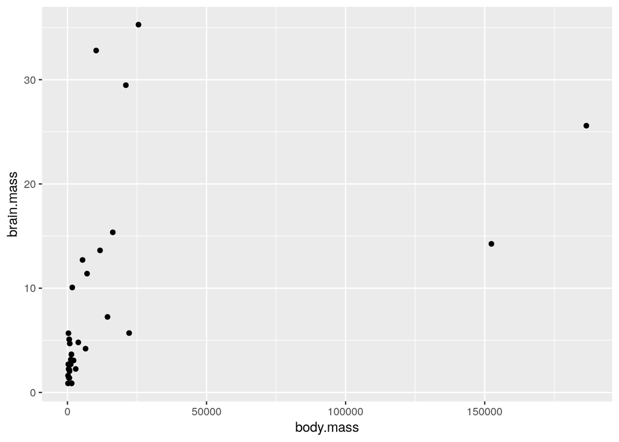

```r
ggplot(data, aes(x = body.mass, y = brain.mass)) +
  geom_point() # add points
```

Colour the points according to whether the species is lecithotrophic or matrotrophic.

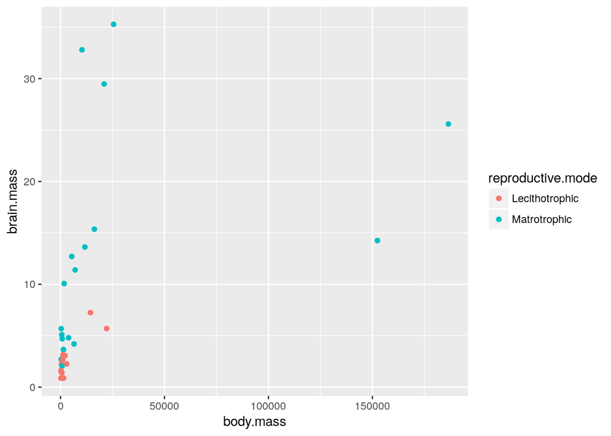

```r
ggplot(data,aes(x = body.mass,y = brain.mass)) +
  geom_point(aes(colour = reproductive.mode))
```

This can be more easily be specified in the `aes()` section in the `ggplot` statement:

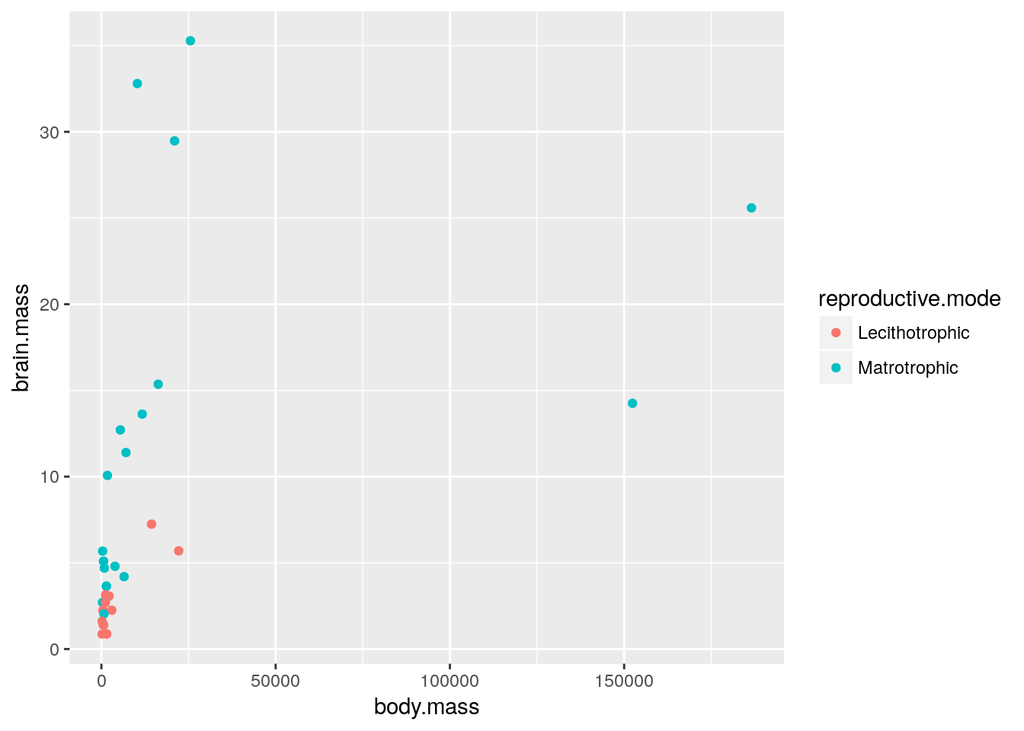

```r
ggplot(data,aes(x = body.mass,y = brain.mass, colour = reproductive.mode)) +
  geom_point()
```

Add a line to the points:

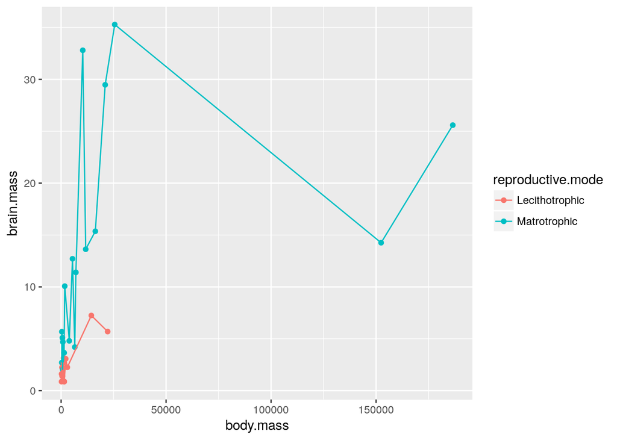

```r
ggplot(data,aes(x = body.mass,y = brain.mass, colour = reproductive.mode)) +
  geom_point() +
  geom_line()
```

Define your own colours, label axes, and select a theme (these are `ggplot` functions starting with `theme_`:

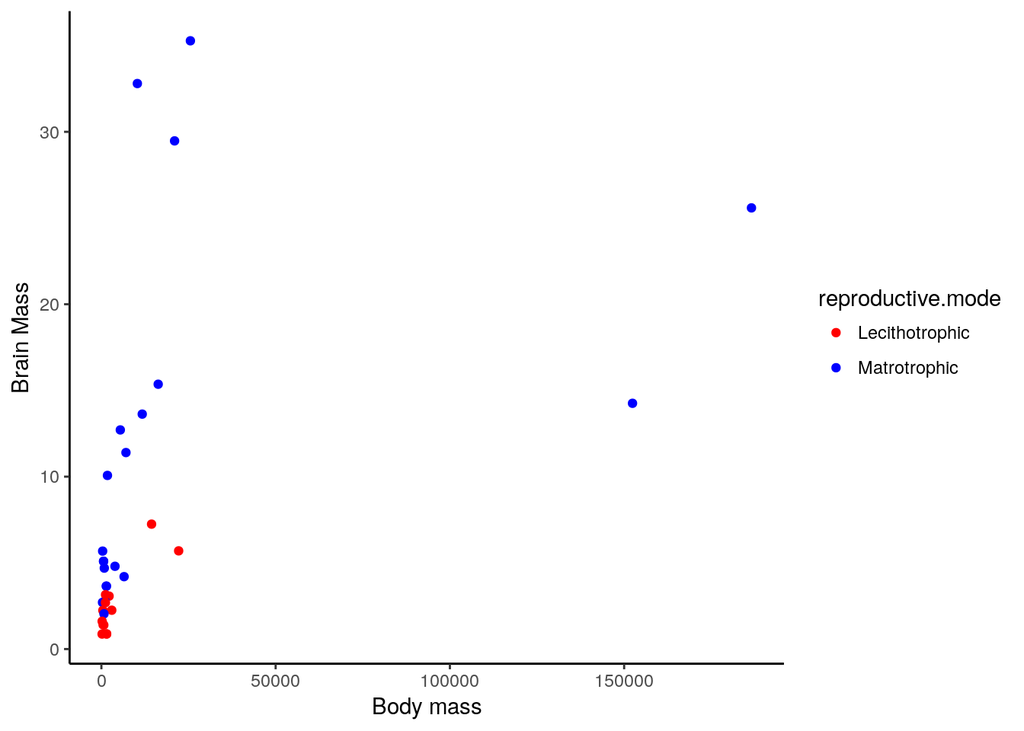

```r
ggplot(data,aes(x = body.mass,y = brain.mass, colour = reproductive.mode)) +
  geom_point() +
  scale_color_manual(name = "reproductive.mode",
                     values = c("Lecithotrophic" = "red",
                                  "Matrotrophic" = "blue")) +
  xlab("Body mass") + ylab("Brain Mass") +
  theme_classic() # there are many other themes to choose from!
```

## Basic introduction to stats in R

Run a t-test on you data. Note that you can specify analyses in R in most functions using a formula notation (see `?formula` for more information). This has the `~` symbol which denotes “by”. In the case below, we are trying to compare brain mass **by** species. However, what is the error message?

```r
t.test(data$brain.mass ~ data$species)
```

```
## Error in t.test.formula(data$brain.mass ~ data$species): grouping factor must have exactly 2 levels
```

The error message is telling you that you have more than 2 levels, i.e. more than two species in your dataset. Therefore subset the dataset to include only 2 species.

```r
mylioraj <- subset(data, data$family %in% c("Rajidae", "Myliobatidae"))
```

Now run the t.test:

```r
t.test(mylioraj$telecephalon ~ mylioraj$family)
```

```
##
##  Welch Two Sample t-test
##
## data:  mylioraj$telecephalon by mylioraj$family
## t = 3.194, df = 2.0152, p-value = 0.08478
## alternative hypothesis: true difference in means is not equal to 0
## 95 percent confidence interval:
##  -1.072948  7.433214
## sample estimates:
## mean in group Myliobatidae      mean in group Rajidae
##                  3.5816800                  0.4015471
```

Run a t-test to see if brain.mass is different between the two reproductive modes.

```r
t.test(data$brain.mass ~ data$reproductive.mode)
```

```
##
##  Welch Two Sample t-test
##
## data:  data$brain.mass by data$reproductive.mode
## t = -3.8987, df = 21.855, p-value = 0.0007795
## alternative hypothesis: true difference in means is not equal to 0
## 95 percent confidence interval:
##  -13.981306  -4.269343
## sample estimates:
## mean in group Lecithotrophic   mean in group Matrotrophic
##                     2.538522                    11.663847
```

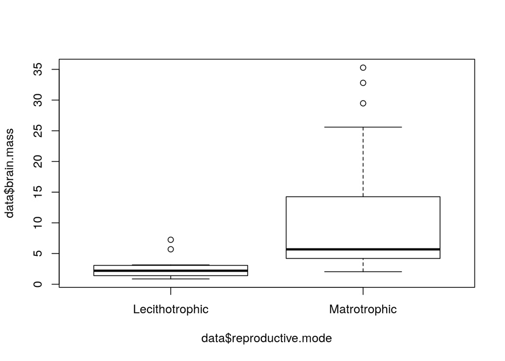

```r
plot(data$brain.mass ~ data$reproductive.mode)
```

Try an anova to test for difference in brain.mass betweem all families. Make sure subject column is a factor, so that it’s not treated as a continuous variable.

```r
str(data)
```

```
## Classes 'tbl_df', 'tbl' and 'data.frame':    35 obs. of  13 variables:
##  $ tribe            : Factor w/ 3 levels "Batoids","Chimaeras",..: 1 3 3 3 2 1 3 1 3 3 ...
##  $ superorder       : Factor w/ 4 levels "Batoidea","Galeomorpha",..: 1 2 2 2 3 1 2 1 2 4 ...
##  $ order            : Factor w/ 9 levels "Carcharhiniformes",..: 7 1 1 1 2 8 6 5 1 3 ...
##  $ family           : Factor w/ 22 levels "Alopiidae","Brachaeluridae",..: 14 3 17 3 16 15 7 22 3 8 ...
##  $ species          : Factor w/ 32 levels "Alopias_vulpinus",..: 11 30 13 25 24 14 7 32 3 21 ...
##  $ telecephalon     : num  0.297 8.73 0.33 1.566 0.415 ...
##  $ medulla          : num  0.264 1.99 0.2 0.866 1.065 ...
##  $ brain.mass       : num  0.875 15.36 0.87 3.649 2.252 ...
##  $ body.mass        : num  1499 16300 200 1426 2975 ...
##  $ reproductive.mode: Factor w/ 2 levels "Lecithotrophic",..: 1 2 1 2 1 2 1 2 2 1 ...
##  $ habitat          : Factor w/ 4 levels "Deep","Pelagic",..: 1 3 1 2 1 3 3 4 3 4 ...
##  $ depth            : num  662 50 476 50 1025 ...
##  $ bodymasskg       : num  1.5 16.3 0.2 1.43 2.98 ...
```

Ours is a factor but if it wasn’t you would run:

```r
data$family <- factor(data$family)
```

Run the anova

```r
aov1 <- aov(brain.mass ~ family, data = data)
```

Check the output. You can use the `boxplot` function from base R to plot the data:

```r
summary(aov1)
```

```
##             Df Sum Sq Mean Sq F value Pr(>F)
## family      21   1782   84.88   0.952  0.555
## Residuals   13   1159   89.18
```

```r
model.tables(aov1, "means")
```

```
## Tables of means
## Grand mean
##
## 8.013717
##
##  family
##     Alopiidae Brachaeluridae Carcharhinidae Centrophoridae Chimaeridae
##          11.4          1.393          10.68          2.695       7.244
## rep       1.0          1.000           7.00          1.000       1.000
##     Dasyatidae Hemiscyllidae Hexanchidae Lamnidae Myliobatidae
##          17.58          2.16       5.695    25.59         7.63
## rep       2.00          1.00       1.000     1.00         3.00
##     Odontaspidae Pseudocarchariidae Pseudotriakidae Rajidae Rhinobatidae
##            14.25                4.8           2.782   1.192        13.63
## rep         1.00                1.0           1.000   4.000         1.00
##     Rhinochimaeridae Scyliorhinidae Somniosidae Sphyrnidae Squalidae
##                2.661         0.8698       4.199       32.8     2.243
## rep            2.000         1.0000       1.000        1.0     1.000
##     Triakidae Urotrygonidae
##         3.151         2.705
## rep     1.000         1.000
```

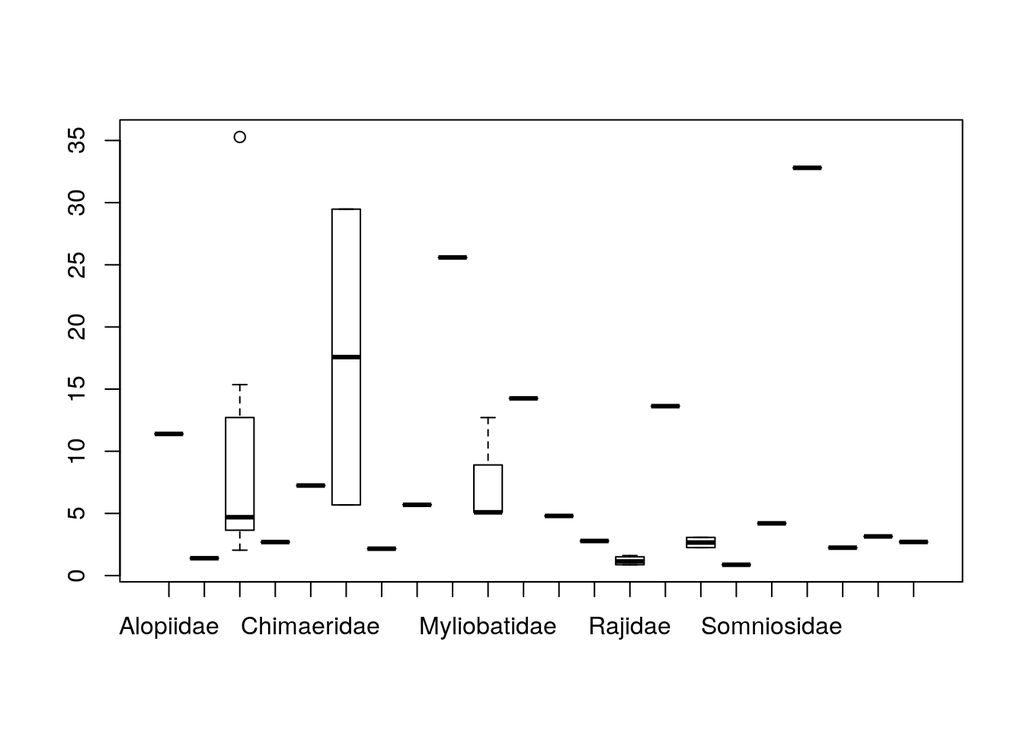

```r
boxplot(brain.mass ~ family, data = data)
```

Run an anove between family and habitat. In formulas, you can use the `+` symbol to add more variables. In the case below, compare body mass **by** family **and** habitat:

```r
aov2 <- aov(body.mass ~ family + habitat, data = data)
summary(aov2)
```

```
##             Df    Sum Sq   Mean Sq F value   Pr(>F)
## family      21 5.236e+10 2.493e+09  31.983 1.49e-06 ***
## habitat      3 4.748e+07 1.583e+07   0.203    0.892
## Residuals   10 7.796e+08 7.796e+07
## ---
## Signif. codes:  0 '***' 0.001 '**' 0.01 '*' 0.05 '.' 0.1 ' ' 1
```

```r
model.tables(aov2, "means")
```

```
## Tables of means
## Grand mean
##
## 14448.14
##
##  family
##     Alopiidae Brachaeluridae Carcharhinidae Centrophoridae Chimaeridae
##          7050            690           6859           1163       14400
## rep         1              1              7              1           1
##     Dasyatidae Hemiscyllidae Hexanchidae Lamnidae Myliobatidae
##          10680           700       22171   186533         2228
## rep          2             1           1        1            3
##     Odontaspidae Pseudocarchariidae Pseudotriakidae Rajidae Rhinobatidae
##           152400               3900            1045   927.6        11720
## rep            1                  1               1     4.0            1
##     Rhinochimaeridae Scyliorhinidae Somniosidae Sphyrnidae Squalidae
##                 2590            200        6512      10320     423.8
## rep                2              1           1          1       1.0
##     Triakidae Urotrygonidae
##          1194         316.4
## rep         1           1.0
##
##  habitat
##      Deep Pelagic  Reef Shelf
##     14488   14370 15188 13630
## rep    11       7     9     8
```

Run an anova:

```r
aov2 <- aov(body.mass ~ family + habitat, data = data)
summary(aov2)
```

```
##             Df    Sum Sq   Mean Sq F value   Pr(>F)
## family      21 5.236e+10 2.493e+09  31.983 1.49e-06 ***
## habitat      3 4.748e+07 1.583e+07   0.203    0.892
## Residuals   10 7.796e+08 7.796e+07
## ---
## Signif. codes:  0 '***' 0.001 '**' 0.01 '*' 0.05 '.' 0.1 ' ' 1
```

```r
model.tables(aov2, "means")
```

[output not shown]

### Linear models/regressions

The `lm` function provides the basic functionality in R to do simple linear regressions. It is a very important function to understand given that most other analyses (GLMS, mixed-effect models, etc.) use the same syntax as the `lm` function (the formula structure), and are basically extensions of it.

Run a linear model with the `lm` function.

```r
lm(telecephalon ~ medulla, data = data)
```

```
##
## Call:
## lm(formula = telecephalon ~ medulla, data = data)
##
## Coefficients:
## (Intercept)      medulla
##     -0.5813       2.9375
```

Create a plot that has telecephalon on the y-axis and medulla on the x-axis.

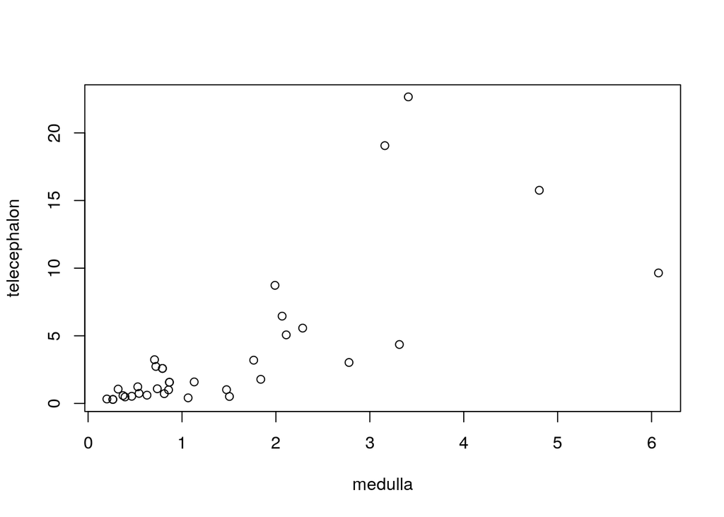

```r
plot(telecephalon ~ medulla, data = data)
```

Plot the data, make it look good, add a title etc. Add a line that shows the model outputs using the `abline` function with the `lm` function nested within it. We are also using the `plot` function from base R, which as you can see is less intuitive than `ggplot`:

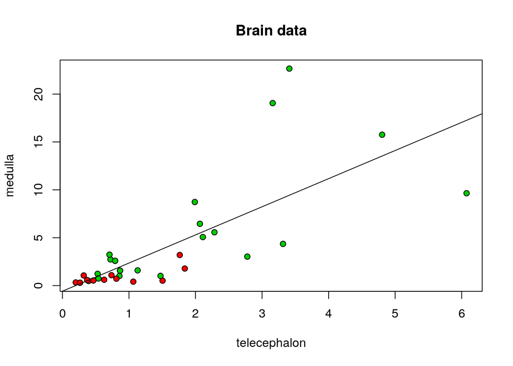

[figure not shown]

```r
plot(telecephalon ~ medulla, data = data, pch = 21,
     bg = c("red","green3","blue")[unclass(data$reproductive.mode)],
     main = "Brain data", xlab = "telecephalon", ylab = "medulla")

abline(lm(telecephalon ~ medulla , data = data), col = "black")
```